# Baseball with R - Chapter 1

Greg Jackson

July 13, 2018

## Baseball With R

The purpose of this is to work through examples in the book “Baseball with R” plus some extra ideas. In Chapter 1, the book suggests downloading a the file from online using 2012 data.  
As there is now a ‘Lahman’ package with access to this data, I will use this instead.

The tables can be accessed directly through this package as shown below, extracting Babe Ruth’s data for simplicity and for team data the Yankees with Babe Ruth

```
##   playerID yearID stint teamID lgID   G  AB   R   H X2B X3B HR RBI SB CS
## 1 ruthba01   1914     1    BOS   AL   5  10   1   2   1   0  0   2  0 NA
## 2 ruthba01   1915     1    BOS   AL  42  92  16  29  10   1  4  21  0 NA
## 3 ruthba01   1916     1    BOS   AL  67 136  18  37   5   3  3  15  0 NA
## 4 ruthba01   1917     1    BOS   AL  52 123  14  40   6   3  2  12  0 NA
## 5 ruthba01   1918     1    BOS   AL  95 317  50  95  26  11 11  66  6 NA
## 6 ruthba01   1919     1    BOS   AL 130 432 103 139  34  12 29 114  7 NA
##    BB SO IBB HBP SH SF GIDP
## 1   0  4  NA   0  0 NA   NA
## 2   9 23  NA   0  2 NA   NA
## 3  10 23  NA   0  4 NA   NA
## 4  12 18  NA   0  7 NA   NA
## 5  58 58  NA   2  3 NA   NA
## 6 101 58  NA   6  3 NA   NA
```

```
##   playerID yearID stint teamID lgID  W  L  G GS CG SHO SV IPouts   H ER HR
## 1 ruthba01   1914     1    BOS   AL  2  1  4  3  1   0  0     69  21 10  1
## 2 ruthba01   1915     1    BOS   AL 18  8 32 28 16   1  0    653 166 59  3
## 3 ruthba01   1916     1    BOS   AL 23 12 44 41 23   9  1    971 230 63  0
## 4 ruthba01   1917     1    BOS   AL 24 13 41 38 35   6  2    979 244 73  2
## 5 ruthba01   1918     1    BOS   AL 13  7 20 19 18   1  0    499 125 41  1
## 6 ruthba01   1919     1    BOS   AL  9  5 17 15 12   0  1    400 148 44  2
##    BB  SO BAOpp  ERA IBB WP HBP BK  BFP GF  R SH SF GIDP
## 1   7   3  0.23 3.91  NA  0   0  0  100  0 12 NA NA   NA
## 2  85 112  0.21 2.44  NA  9   6  1  895  3 80 NA NA   NA
## 3 118 170  0.20 1.75  NA  3   8  1 1300  3 83 NA NA   NA
## 4 108 128  0.21 2.01  NA  5  11  0 1313  2 91 NA NA   NA
## 5  49  40  0.21 2.22  NA  3   2  1  660  0 51 NA NA   NA
## 6  58  30  0.29 2.97  NA  5   2  1  591  2 59 NA NA   NA
```

```
##   playerID yearID stint teamID lgID POS  G GS InnOuts  PO   A E DP PB WP
## 1 ruthba01   1914     1    BOS   AL   P  4 NA      NA   0   7 0  0 NA NA
## 2 ruthba01   1915     1    BOS   AL   P 32 NA      NA  17  63 2  3 NA NA
## 3 ruthba01   1916     1    BOS   AL   P 44 NA      NA  24  83 3  6 NA NA
## 4 ruthba01   1917     1    BOS   AL   P 41 NA      NA  19 101 2  4 NA NA
## 5 ruthba01   1918     1    BOS   AL  1B 13 NA      NA 130   6 5  8 NA NA
## 6 ruthba01   1918     1    BOS   AL  OF 59 NA      NA 121   8 7  3 NA NA
##   SB CS ZR
## 1 NA NA NA
## 2 NA NA NA
## 3 NA NA NA
## 4 NA NA NA
## 5 NA NA NA
## 6 NA NA NA
```

```
##   yearID lgID teamID franchID divID Rank   G Ghome  W  L DivWin WCWin
## 1   1920   AL    NYA      NYY  <NA>    3 154    77 95 59   <NA>  <NA>
## 2   1921   AL    NYA      NYY  <NA>    1 153    78 98 55   <NA>  <NA>
## 3   1922   AL    NYA      NYY  <NA>    1 154    77 94 60   <NA>  <NA>
## 4   1923   AL    NYA      NYY  <NA>    1 152    76 98 54   <NA>  <NA>
## 5   1924   AL    NYA      NYY  <NA>    2 153    78 89 63   <NA>  <NA>
## 6   1925   AL    NYA      NYY  <NA>    7 156    79 69 85   <NA>  <NA>
##   LgWin WSWin   R   AB    H X2B X3B  HR  BB  SO SB CS HBP SF  RA  ER  ERA
## 1     N     N 838 5176 1448 268  71 115 539 626 64 82  NA NA 629 505 3.32
## 2     Y     N 948 5249 1576 285  87 134 588 569 89 64  NA NA 708 579 3.82
## 3     Y     N 758 5245 1504 220  75  95 497 532 62 59  NA NA 618 525 3.39
## 4     Y     Y 823 5347 1554 231  79 105 521 516 69 74  NA NA 622 555 3.62
## 5     N     N 798 5240 1516 248  86  98 478 420 69 64  NA NA 667 583 3.86
## 6     N     N 706 5353 1471 247  74 110 470 482 67 73  NA NA 774 667 4.33
##    CG SHO SV IPouts   HA HRA BBA SOA   E  DP    FP             name
## 1  88  15 11   4104 1414  48 420 480 193 129 0.970 New York Yankees
## 2  92   8 15   4092 1461  51 470 481 220 138 0.965 New York Yankees
## 3 100   7 14   4179 1402  73 423 458 155 122 0.975 New York Yankees
## 4 101   9 10   4140 1365  68 491 506 144 131 0.977 New York Yankees
## 5  76  13 13   4077 1483  59 522 487 154 131 0.975 New York Yankees
## 6  80   8 13   4161 1560  78 505 492 162 150 0.974 New York Yankees
##               park attendance BPF PPF teamIDBR teamIDlahman45 teamIDretro
## 1  Polo Grounds IV    1289422 104 101      NYY            NYA         NYA
## 2  Polo Grounds IV    1230696 102  98      NYY            NYA         NYA
## 3  Polo Grounds IV    1026134 102  98      NYY            NYA         NYA
## 4 Yankee Stadium I    1007066 103 100      NYY            NYA         NYA
## 5 Yankee Stadium I    1053533 100  99      NYY            NYA         NYA
## 6 Yankee Stadium I     697267  98  97      NYY            NYA         NYA
```

# Answering questions

1. The home run rate stayed fairly low until just before 1920 when it went up steadily until almost 1940, then after dipping below 1 again for a couple of years it went up rapidly, ending up above 2 per game for much of “Steroid era”. It went down again until about 2015 before spiking up suddenly.

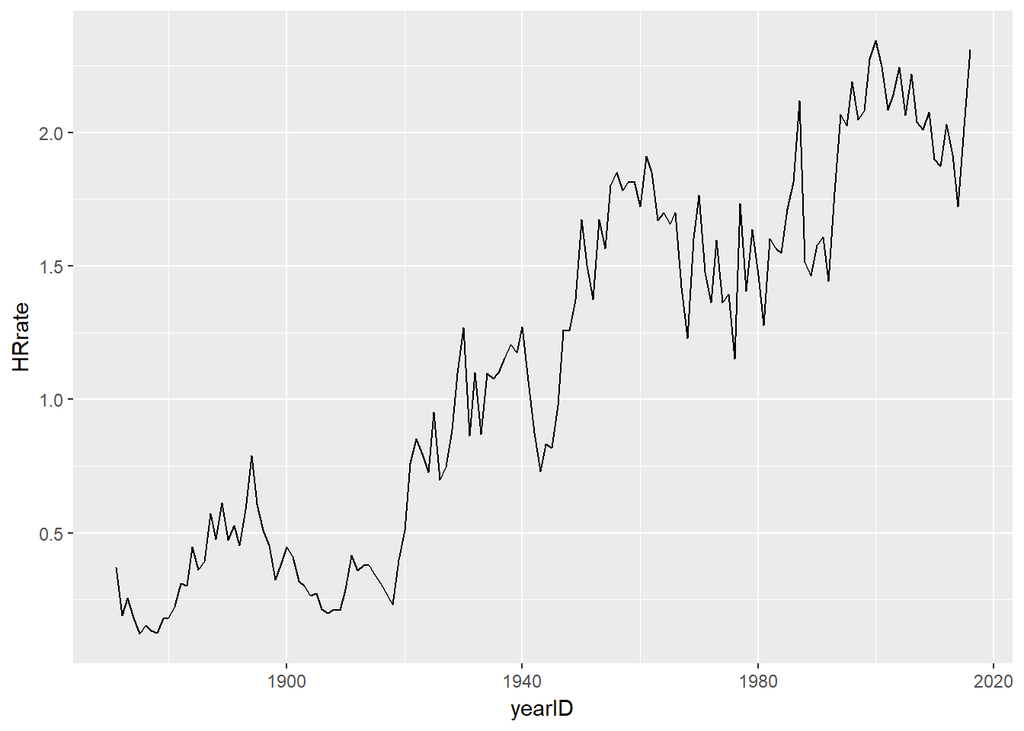

The climb in strikeout rate has been more steady, though it dropped from about 1965-1980 before climbing steadily to now over 15 per game.

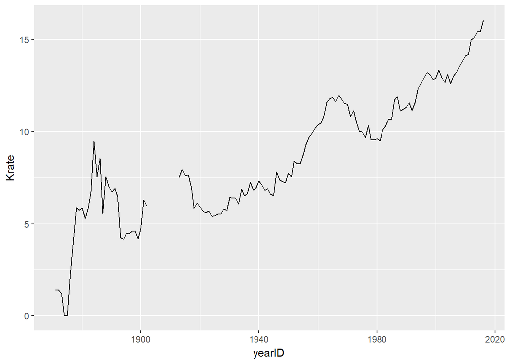